# xwMOOC 자연어 처리 - 텍스트

케인즈 vs 하이에크 - 토픽 모형

xwMOOC

Tidyverse Korea

2019-01-29

# 1 토픽 모형(topic modeling) [^1]

문서가 많은 경우 혹은 책과 같이 다수 장(chapter)으로 구성된 경우 이를 추상화해서 토픽(topic, 주제)를 추출할 필요가 있다. Latent Dirichlet allocation (LDA)가 토픽 모형으로 많이 알려져 있으며 많이 사용되고 있다.

- 모든 문서는 화제(topic)가 뒤섞인 것이다. (Every document is a mixture of topics.), 즉, 문서 각각은 몇개 화제가 일정 비율로 뒤섞인 것으로 볼 수 있다. 예를 들어, 첫번째 문서는 화제 1이 10%, 화제 2가 90%, 반면에서 두번째 문서는 화제 1이 70%, 화제3이 20%, 화제2가 10% 뒤섞인 것으로 본다.
- 모든 화제(topic)은 단어(word)가 뒤섞인 것이다. (Every topic is a mixture of words.), 즉, OO일보 2019-01-29 일자 뉴스기사는 “정치”에서 화제를 하나뽑고, “연예”에서 화제를 하나 뽑아 작성되었다. 정치 화제에서 가장 많이 회자된 단어는 “대통령”, “국회”, “정부”를 들 수 있고, 연예 화제에서는 “영화”, “SNS”, “배우”를 둘 수 있다. 특히 “예산” 같은 단어는 정치나 연예 모두 공통으로 사용되는 중요한 단어가 될 수 있다.

# 2 케인즈 vs 하이에크 저서 데이터 [^2]

`pdf_text` 함수로 `.pdf` 파일을 R에서 처리 가능한 문자열을 뽑아내서 객체에 담아낸다.

```r
library(pdftools)
library(tidyverse)
library(tidytext)

keynes_pdf <- pdf_text("data/generaltheory.pdf")
hayek_pdf <- pdf_text("data/The-Road-to-Serfdom-F.A.-Hayek.pdf")

keynes_df <- keynes_pdf %>%
  tbl_df() %>%
  mutate(book = "케인즈") %>%
  unnest_tokens(word, value)

hayek_df <- hayek_pdf %>%
  tbl_df() %>%
  mutate(book = "하이에크") %>%
  unnest_tokens(word, value)

data(stop_words)

book_df <- bind_rows(keynes_df, hayek_df) %>%
  mutate(word = str_to_lower(word)) %>%
  anti_join(stop_words)
```

## 2.1 케인즈 - 일반이론

케인즈 “일반이론” 책을 각 Chapter 장으로 쪼갠다. 이를 위해서 정규표현식을 동원해서 각 장의 첫번째 장을 추출하고 매칭되지 않는 것을 `NA`로 처리한 후에 `tidyr::fill()` 함수로 채워넣고 기타 불필요한 서문과 부록(Appendix)을 제거시킨다.

```r
kbook_df <- keynes_pdf %>%
  tbl_df() %>%
  mutate(text = str_split(value, "\r\n")) %>%
  unnest(text) %>%
  select(-value) %>%
  mutate(book="케인즈")

kbook_df %>%
  filter(str_detect(text, "^Chapter [0-9]+|^Appendix [0-3]")) %>% tail
```

```
# A tibble: 6 x 2
  text       book
  <chr>      <chr>
1 Chapter 22 케인즈
2 Chapter 23 케인즈
3 Chapter 24 케인즈
4 Appendix 1 케인즈
5 Appendix 2 케인즈
6 Appendix 3 케인즈
```

```r
kbbok_chap_df <- kbook_df %>%
  mutate(chapter = ifelse(str_detect(text, "^Chapter [0-9]{0,2}[^\r\n]$|^Appendix [0-3]"), text, NA)) %>%
  tidyr::fill(chapter) %>%
  filter(str_detect(chapter, "Chapter"))
```

## 2.2 각장(Chapter) → 단어(Word)

앞서 “일반이론”을 각 장별로 나눠서 총 24장으로 구성된 것을 확인하고 제대로 검증하기 위해서 단어 갯수를 불용어 처리해서 세어본다.

```r
kbbok_chap_df %>%
  select(book, chapter, text) %>%
  unnest_tokens(word, text) %>%
    anti_join(stop_words) %>%
    count(word, sort=TRUE)
```

```
# A tibble: 6,008 x 2
   word           n
   <chr>      <int>
 1 rate         759
 2 money        724
 3 employment   623
 4 investment   543
 5 capital      510
 6 income       377
 7 marginal     367
 8 wage         338
 9 demand       337
10 cost         322
# ... with 5,998 more rows
```

`ggrepel` 팩키지를 활용하여 총 24장에 걸쳐 가장 많이 회자되는 단어가 어떤 것이 있는지 각 장별로 15개씩 뽑아서 이를 시각화한다.

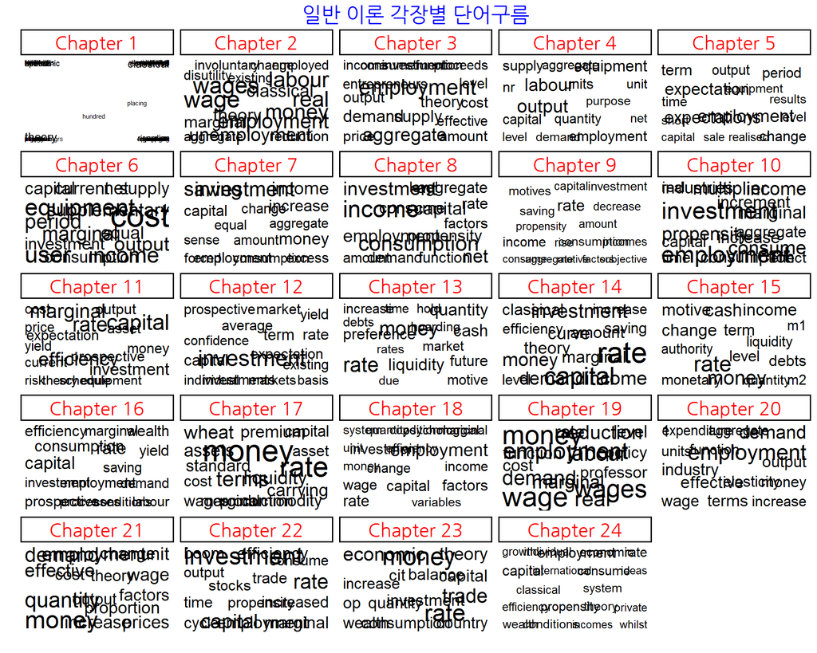

```r
library(ggrepel)
library(extrafont)
loadfonts()

kbbok_chap_df %>%
  select(chapter, text) %>%
  mutate(chapter = factor(chapter, levels = paste("Chapter", seq(1:24)))) %>%
  unnest_tokens(word, text) %>%
    anti_join(stop_words) %>%
    group_by(chapter) %>%
    count(chapter, word, sort=TRUE) %>%
    top_n(15, wt=n) %>%
    ggplot(aes(x = 1, y = 1, size = n, label = word)) +
      geom_text_repel(segment.size = 0, force = 100, segment.color = 'white', segment.alpha = 0.01) +
      scale_size(range = c(2, 10), guide = FALSE) +
      scale_y_continuous(breaks = NULL) +
      scale_x_continuous(breaks = NULL) +
      labs(x = '', y = '', title = "일반 이론 각장별 단어구름") +
      facet_wrap(~ chapter) +
      theme_classic(base_family="NanumGothic") +
      theme(strip.text = element_text(color="red", size=16, lineheight=5.0),
               plot.title = element_text(colour = "blue",
               size = 18, hjust = 0.5, vjust = 0.8, angle = 0))
```

# 3 각장(Chapter) 핵심용어 - TF-IDF

주제(topic) 모형으로 들어가기 전에 각 장별로 사용된 핵심용어가 어떤 것이 있는지 살펴보자. 이를 위해서 `TF-IDF`를 사용한다. 일반이론은 24장으로 구성되어 있어 TF-IDF를 한장에 시각화하는데 한계가 있어 각 장별로 핵심용어 7개만 추출한다.

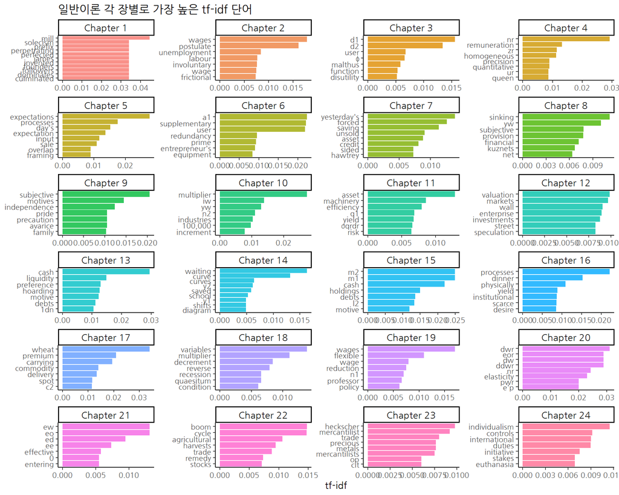

```r
library(drlib)

kbook_tf_idf <- kbbok_chap_df %>%
  select(-book) %>%
  unnest_tokens(word, text) %>%
  anti_join(stop_words) %>%
  count(chapter, word, sort = TRUE) %>%
  bind_tf_idf(word, chapter, n) %>%
  arrange(-tf_idf) %>%
  group_by(chapter) %>%
  top_n(7) %>%
  ungroup()

kbook_tf_idf %>%
    mutate(word = reorder_within(word, tf_idf, chapter)) %>%
    mutate(chapter = factor(chapter, levels = paste("Chapter", seq(1:24)))) %>%
    ggplot(aes(word, tf_idf, fill = chapter)) +
    geom_col(alpha = 0.8, show.legend = FALSE) +
    facet_wrap(~ chapter, scales = "free", ncol = 4) +
    scale_x_reordered() +
    coord_flip() +
    theme_classic(base_family="NanumGothic") +
    theme(strip.text=element_text(size=11)) +
    labs(x = NULL, y = "tf-idf",
         title = "일반이론 각 장별로 가장 높은 tf-idf 단어")
```

# 4 일반이론 주제(topic) [^3]

`tf-idf` 분석을 이어 토픽 모형으로 진행하는데 팩키지가 필요한데 과거 속도, 자바 의존성이 문제가 되어 번거러웠으나, `stm` 팩키지의 등장으로 C++로 작성되어 자바 의존성과 속도 문제가 모두 해결되고 전문가들의 평판도 좋다.

`stm()`함수는 인자로 문서-단어 행렬(document-term matrix) 혹은 `quanteda` 팩키지 희소 행렬(sparse matrix) 혹은 `dfm` 자료형을 전달하여야 한다. 깔끔한 텍스트 데이터로 정제된 것을 문서(스토리)-단어 행렬로 `count()`, `cast_dfm()` 함수를 연결하여 구현해낸다. 동일하게 `count()`, `cast_sparse()` 함수를 연결하여 희소행렬도 구현할 수 있다.

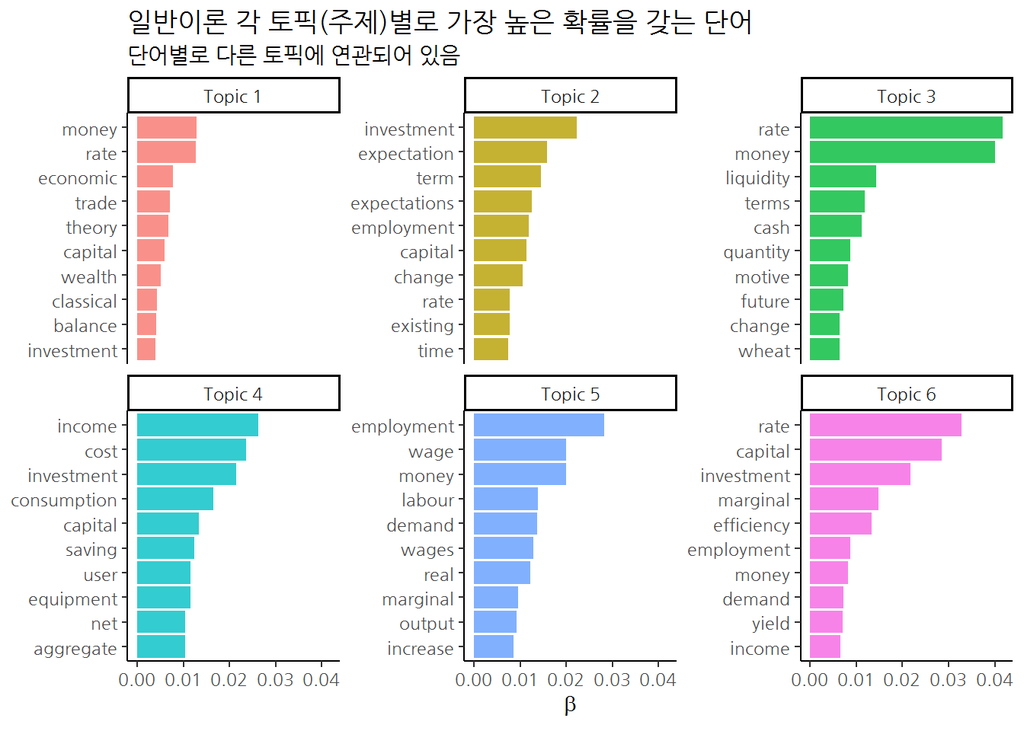

```r
library(quanteda)
library(stm)

kbook_dfm <- kbbok_chap_df %>%
  select(-book) %>%
  unnest_tokens(word, text) %>%
  anti_join(stop_words) %>%
  count(chapter, word, sort = TRUE) %>%
  cast_dfm(chapter, word, n)

ktopic_model <- stm(kbook_dfm, K = 6,
                   verbose = FALSE, init.type = "Spectral")

td_beta <- tidy(ktopic_model)

td_beta %>%
    group_by(topic) %>%
    top_n(10, beta) %>%
    ungroup() %>%
    mutate(topic = paste0("Topic ", topic),
           term = reorder_within(term, beta, topic)) %>%
    ggplot(aes(term, beta, fill = as.factor(topic))) +
    geom_col(alpha = 0.8, show.legend = FALSE) +
    facet_wrap(~ topic, scales = "free_y") +
    coord_flip() +
    scale_x_reordered() +
    theme_classic(base_family="NanumGothic") +
    labs(x = NULL, y = expression(beta),
         title = "일반이론 각 토픽(주제)별로 가장 높은 확률을 갖는 단어",
         subtitle = "단어별로 다른 토픽에 연관되어 있음")
```

[^1]: [단어구름에서 토픽모형, From World Cloud to Toptic Modeling](https://statkclee.github.io/text/silge-topic-modeling.html)
[^2]: [Julia Silge and David Robinson (2018-12-21), “Text Mining with R - A Tidy Approach”](https://www.tidytextmining.com/)
[^3]: [JULIA SILGE (Sep 8, 2018), “TRAINING, EVALUATING, AND INTERPRETING TOPIC MODELS”](https://juliasilge.com/blog/evaluating-stm/)